# Klassifikation von KHK-Risiken anhand medizinischer Daten

Dieses Notebook beschäftigt sich mit der Anwendung verschiedener Verfahren des maschinellen Lernens auf einen klinischen Datensatz zur Klassifikation des Risikos für koronare Herzkrankheiten (KHK).

Name: Niklas Werthmann  
Matrik. Nr.: xxxxxxxxxxxxxxxx  
Kurs: xxxxxxxxxxxx

## 1. Import notwendiger Bibliotheken und Laden der Daten

```python
# Bibliotheken importieren
import pandas as pd
import numpy as np
%matplotlib inline
import matplotlib.pyplot as plt
import seaborn as sns

from sklearn.model_selection import train_test_split, StratifiedKFold
from sklearn.preprocessing import StandardScaler
from sklearn.decomposition import PCA
from sklearn.neighbors import KNeighborsClassifier
from sklearn.svm import SVC
from sklearn.linear_model import LogisticRegression
from sklearn.tree import DecisionTreeClassifier
from sklearn.ensemble import RandomForestClassifier, GradientBoostingClassifier
from sklearn.neural_network import MLPClassifier
from sklearn.metrics import accuracy_score
from sklearn.model_selection import GridSearchCV
from sklearn.inspection import permutation_importance
from sklearn.preprocessing import PolynomialFeatures
from sklearn.manifold import TSNE


# Laden des Datensatzes
df = pd.read_csv("KHK_Klassifikation.csv")
```

## 2. Übersicht & Korrektur des Datensatzes

### 2.1 Datentypen, Spaltennamen & Inhalt

```python
df.info()
df.head()
```

```
<class 'pandas.core.frame.DataFrame'>
RangeIndex: 918 entries, 0 to 917
Data columns (total 10 columns):
 #   Column      Non-Null Count  Dtype
---  ------      --------------  -----
 0   Alter       918 non-null    int64
 1   Geschlecht  918 non-null    object
 2   Blutdruck   918 non-null    int64
 3   Chol        918 non-null    int64
 4   Blutzucker  918 non-null    int64
 5   EKG         918 non-null    object
 6   HFmax       918 non-null    int64
 7   AP          918 non-null    object
 8   RZ          918 non-null    float64
 9   KHK         918 non-null    int64
dtypes: float64(1), int64(6), object(3)
memory usage: 71.8+ KB
```

|  | Alter | Geschlecht | Blutdruck | Chol | Blutzucker | EKG | HFmax | AP | RZ | KHK |
| --- | --- | --- | --- | --- | --- | --- | --- | --- | --- | --- |
| 0 | 40 | M | 140 | 289 | 0 | Normal | 172 | N | 0.0 | 0 |
| 1 | 49 | F | 160 | 180 | 0 | Normal | 156 | N | 1.0 | 1 |
| 2 | 37 | M | 130 | 283 | 0 | ST | 98 | N | 0.0 | 0 |
| 3 | 48 | F | 138 | 214 | 0 | Normal | 108 | Y | 1.5 | 1 |
| 4 | 54 | M | 150 | 195 | 0 | Normal | 122 | N | 0.0 | 0 |

### 2.2 Dimensionen & Anzahl der Datenpunkte

```python
df.shape
```

```
(918, 10)
```

Es liegen 918 Datenpunkte vor und 10 Dimensionen

### 2.3 Korrektur

In Abschnitt 2.1 lässt sich erkennen, dass einige Datentypen nicht korrekt sind. Geschlecht, EKG, AP und KHK müssen in die im Kontext korrekten Datentypen umgewandelt werden.

```python
# Konvertiere die Variable 'Geschlecht' in eine kategorische Variable
df['Geschlecht'] = df['Geschlecht'].astype('category')

# Konvertiere die Variable 'EKG' in eine kategorische Variable
df['EKG'] = df['EKG'].astype('category')

# Konvertiere die Variable 'AP' in eine kategorische Variable (liegt bereits als kat. Variable vor, jedoch ist der Datentyp 'object')
df['AP'] = df['AP'].astype('category')

# Konvertiere die Variable 'KHK' in eine boolsche Variable
df['KHK'] = df['KHK'].astype('bool')
```

#### 2.3.1 Übersicht über den korrigierten Datensatz

```python
df.info()
df.head()
```

```
<class 'pandas.core.frame.DataFrame'>
RangeIndex: 918 entries, 0 to 917
Data columns (total 10 columns):
 #   Column      Non-Null Count  Dtype
---  ------      --------------  -----
 0   Alter       918 non-null    int64
 1   Geschlecht  918 non-null    category
 2   Blutdruck   918 non-null    int64
 3   Chol        918 non-null    int64
 4   Blutzucker  918 non-null    int64
 5   EKG         918 non-null    category
 6   HFmax       918 non-null    int64
 7   AP          918 non-null    category
 8   RZ          918 non-null    float64
 9   KHK         918 non-null    bool
dtypes: bool(1), category(3), float64(1), int64(5)
memory usage: 47.1 KB
```

|  | Alter | Geschlecht | Blutdruck | Chol | Blutzucker | EKG | HFmax | AP | RZ | KHK |
| --- | --- | --- | --- | --- | --- | --- | --- | --- | --- | --- |
| 0 | 40 | M | 140 | 289 | 0 | Normal | 172 | N | 0.0 | False |
| 1 | 49 | F | 160 | 180 | 0 | Normal | 156 | N | 1.0 | True |
| 2 | 37 | M | 130 | 283 | 0 | ST | 98 | N | 0.0 | False |
| 3 | 48 | F | 138 | 214 | 0 | Normal | 108 | Y | 1.5 | True |
| 4 | 54 | M | 150 | 195 | 0 | Normal | 122 | N | 0.0 | False |

Jetzt liegt der Datensatz in der korrekten Form vor und wir können mit der Analyse beginnen, welche Variablen KHK beeinflussen.

## 3. Explorative Datenanalyse

Wir analysieren die Struktur und Verteilung der Daten, untersuchen die Zielvariable und suchen nach Korrelationen zwischen den Features.

### 3.1 Statistische Übersicht

```python
df.describe()
```

|  | Alter | Blutdruck | Chol | Blutzucker | HFmax | RZ |
| --- | --- | --- | --- | --- | --- | --- |
| count | 918.000000 | 918.000000 | 918.000000 | 918.000000 | 918.000000 | 918.000000 |
| mean | 53.510893 | 132.396514 | 198.799564 | 0.233115 | 136.809368 | 0.887364 |
| std | 9.432617 | 18.514154 | 109.384145 | 0.423046 | 25.460334 | 1.066570 |
| min | 28.000000 | 0.000000 | 0.000000 | 0.000000 | 60.000000 | -2.600000 |
| 25% | 47.000000 | 120.000000 | 173.250000 | 0.000000 | 120.000000 | 0.000000 |
| 50% | 54.000000 | 130.000000 | 223.000000 | 0.000000 | 138.000000 | 0.600000 |
| 75% | 60.000000 | 140.000000 | 267.000000 | 0.000000 | 156.000000 | 1.500000 |
| max | 77.000000 | 200.000000 | 603.000000 | 1.000000 | 202.000000 | 6.200000 |

Hier lässt sich u.a erkennen, dass das Durchschnittsalter der Patienten ca. 53 1/2 Jahre beträgt, wobei der jüngste Patient 28 und der älteste 77 Jahre alt ist.

### 3.2 Verteilung der Zielvariable KHK

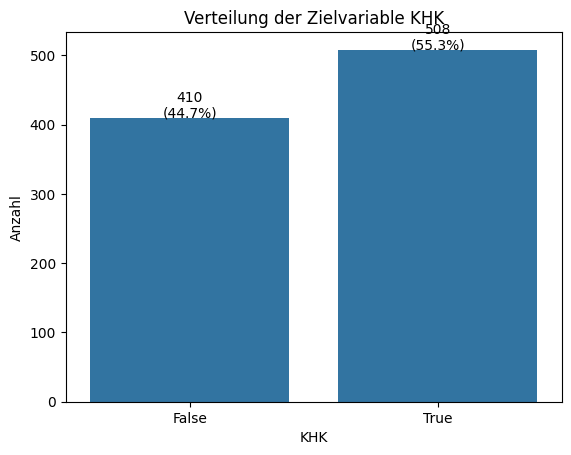

```python
ax = sns.countplot(data=df, x='KHK')
plt.ylabel("Anzahl")
plt.title("Verteilung der Zielvariable KHK")

# Zahlen und Prozentsätze über den Balken anzeigen
for p in ax.patches:
    height = p.get_height()
    ax.annotate(f'{int(height)}\n({height/df["KHK"].count()*100:.1f}%)',
                (p.get_x() + p.get_width() / 2., height),
                ha='center', va='baseline')

plt.show()
```

Von den 918 Patienten des Datensatzes leiden 508 (55.3%) an der Koronaren Herzkrankheit.

### 3.3 Korrelation der Features

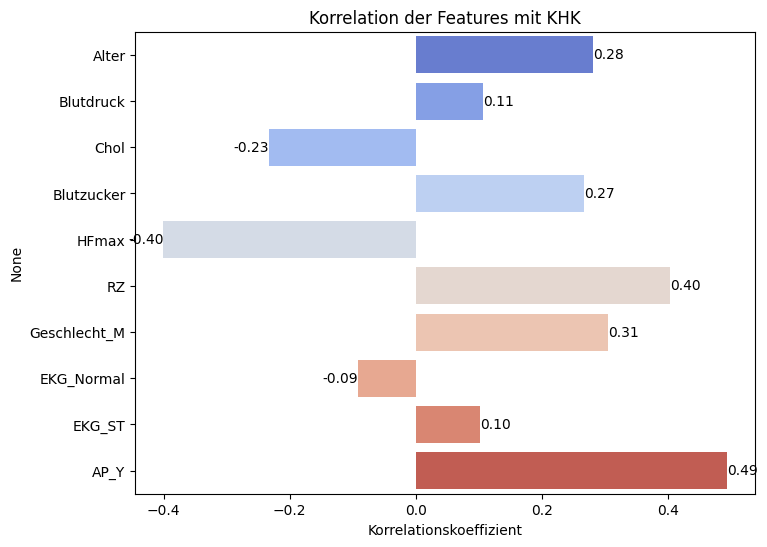

```python
# Umwandlung kategorialer Variablen in numerische Werte
df_encoded = pd.get_dummies(df, drop_first=True)

# Korrelation der Zielvariable KHK mit den anderen Features
khk_corr = df_encoded.corr()["KHK"].drop("KHK")

# Visualisierung der Korrelationen
fig, ax = plt.subplots(figsize=(8, 6))
sns.barplot(x=khk_corr.values, y=khk_corr.index, hue=khk_corr.index, palette="coolwarm", dodge=False, ax=ax)
ax.set_title("Korrelation der Features mit KHK")
ax.set_xlabel("Korrelationskoeffizient")

# Zahlen über den Balken anzeigen
for i in ax.containers:
    ax.bar_label(i, fmt='%.2f')

# Plot speichern - wird in Abschnitt 6.1 benötigt
khk_corr_plot = fig
```

Der Plot zeigt die Korrelation zwischen verschiedenen Features (Variablen) und der Zielgröße **KHK**.

**Wichtige Anmerkung**: Korrelation bedeutet nicht Kausalität! - dies wird indirekt in Abschnitt 6 überprüft

## 4. Datenvorbereitung

Wir trennen die Daten in Features (X) und Zielvariable (y) und führen eine Skalierung durch.

```python
# Features und Zielvariable definieren
X = df_encoded.drop(columns=["KHK"])
y = df_encoded["KHK"]

# Aufteilen in Trainings- und Testdaten
X_train, X_test, y_train, y_test = train_test_split(X, y, test_size=0.2, random_state=1, stratify=y)

# Datensatz standardisieren
scaler = StandardScaler()
X_train_scaled = scaler.fit_transform(X_train)
X_test_scaled = scaler.transform(X_test)
```

Damit sieht der Trainingsdatensatz so aus:

```python
pd.concat([X_train, y_train], axis=1).head()
```

|  | Alter | Blutdruck | Chol | Blutzucker | HFmax | RZ | Geschlecht_M | EKG_Normal | EKG_ST | AP_Y | KHK |
| --- | --- | --- | --- | --- | --- | --- | --- | --- | --- | --- | --- |
| 209 | 54 | 125 | 216 | 0 | 140 | 0.0 | True | True | False | False | True |
| 656 | 62 | 124 | 209 | 0 | 163 | 0.0 | False | True | False | False | False |
| 451 | 64 | 144 | 0 | 0 | 122 | 1.0 | True | False | True | True | True |
| 294 | 32 | 95 | 0 | 1 | 127 | 0.7 | True | True | False | False | True |
| 545 | 48 | 132 | 272 | 0 | 139 | 0.2 | True | False | True | False | False |

... und der Testdatensatz wie folgt:

```python
pd.concat([X_test, y_test], axis=1).head()
```

|  | Alter | Blutdruck | Chol | Blutzucker | HFmax | RZ | Geschlecht_M | EKG_Normal | EKG_ST | AP_Y | KHK |
| --- | --- | --- | --- | --- | --- | --- | --- | --- | --- | --- | --- |
| 417 | 44 | 130 | 209 | 0 | 127 | 0.0 | True | False | True | False | False |
| 395 | 38 | 135 | 0 | 1 | 150 | 0.0 | True | True | False | False | True |
| 901 | 58 | 170 | 225 | 1 | 146 | 2.8 | False | False | False | True | True |
| 624 | 63 | 150 | 407 | 0 | 154 | 4.0 | False | False | False | False | True |
| 414 | 54 | 130 | 0 | 1 | 110 | 3.0 | True | True | False | True | True |

### 4.1 PCA: Dimensionsreduktion und Visualisierung

Wir führen eine PCA durch, um die transformierten Trainingsdaten im zweidimensionalen Raum zu betrachten.

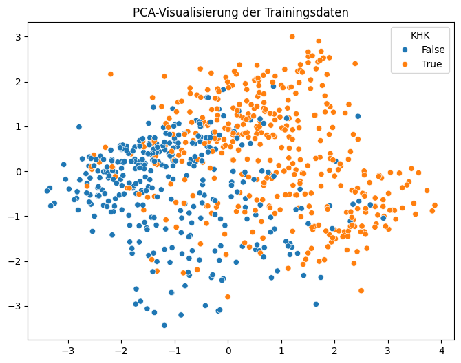

```python
# PCA durchführen
pca = PCA(n_components=2)
X_pca = pca.fit_transform(X_train_scaled)

# Visualisierung
plt.figure(figsize=(8, 6))
sns.scatterplot(x=X_pca[:, 0], y=X_pca[:, 1], hue=y_train)
plt.title("PCA-Visualisierung der Trainingsdaten")
plt.show()
```

In der dargestellten PCA-Visualisierung sind die Datenpunkte in zwei Gruppen (blau und orange) unterteilt. Diese Farben repräsentieren die zwei Klassen: "KHK nicht vorhanden" (blau) und "KHK vorhanden" (orange). Die orangefarbene Gruppe (KHK vorhanden) ist hauptsächlich auf der rechten Seite des Diagramms konzentriert, während die blaue Gruppe (KHK nicht vorhanden) auf der linken Seite liegt. Es lässt sich eine gewisse Trennung der beiden Klassen erkennen, jedoch gibt es auch Bereiche, in denen sich die Klassen überlappen.

**Konsequenz**  
Die Visualisierung deutet auf eine potenziell gute Separierbarkeit hin, da die beiden Gruppen hauptsächlich in unterschiedlichen Bereichen konzentriert sind. Allerdings ist die Überlappung ein Hinweis darauf, dass die Klassen nicht vollständig trennbar sind, was auch die Wahl des Modells beeinflussen könnte. Für eine fundierte Aussage prüfen wir die Separierbarkeit zusätzlich:

Wir beginnen mit der Visualisierungsmethode t-SNE, die nichtlineare Beziehungen abbildet:

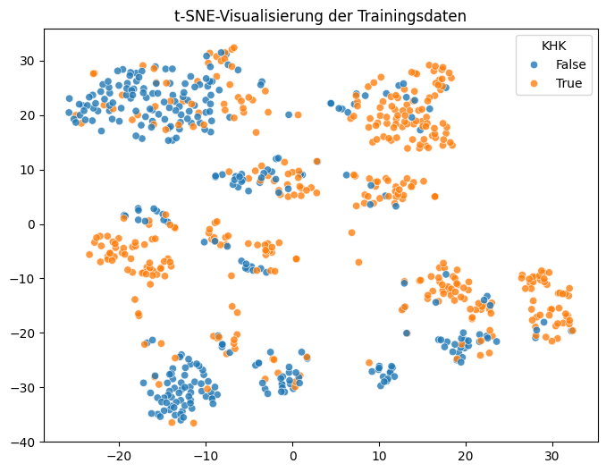

```python
# t-SNE mit 2 Komponenten
tsne = TSNE(n_components=2, random_state=1, perplexity=30, max_iter=1000)
X_tsne = tsne.fit_transform(X_train_scaled)

# Visualisierung
plt.figure(figsize=(8, 6))
sns.scatterplot(x=X_tsne[:, 0], y=X_tsne[:, 1], hue=y_train, alpha=0.8)
plt.title("t-SNE-Visualisierung der Trainingsdaten")
plt.legend(title="KHK", loc="best")
plt.show()
```

Diese Visualisierung zeigt, dass sich die Situation im Vergleich zur PCA-Analyse leicht verbessert hat. Es lassen einige Gruppierungen erkennen und die Datenpunkte der Klassen *KHK vorhanden* und *KHK nicht vorhanden* sind nur teilweise miteinander vermischt. Eine klare Trennung der beiden Gruppen ist nicht erkennbar.

Da die visuelle Analyse keine nützlichen Ergebnisse liefert, wenden wir uns nun verschiedenen Klassifikationsmodellen zu. Diese Modelle sollen uns dabei helfen, die Gruppen *KHK vorhanden* und *KHK nicht vorhanden* algorithmisch abzugrenzen und die zugrunde liegenden Muster in den Daten zu identifizieren.

## 5. Klassifikationsverfahren

Wir wenden sechs verschiedene Klassifikationsverfahren an, darunter kNN, SVM & Random Forest. Abschließend folgt eine Bewertung der Genauigkeit dieser Modelle.

### k-Nearest Neighbors (kNN)

```python
# kNN-Modell
knn = KNeighborsClassifier(n_neighbors=4)
knn.fit(X_train_scaled, y_train)
y_pred_knn = knn.predict(X_test_scaled)
```

### Support Vector Machines (SVM)

```python
# SVM-Modell
svm = SVC(kernel="rbf")
svm.fit(X_train_scaled, y_train)
y_pred_svm = svm.predict(X_test_scaled)
```

### Logistische Regression

```python
# Logistisches Regressionsmodell
log_reg = LogisticRegression()
log_reg.fit(X_train_scaled, y_train)
y_pred_log = log_reg.predict(X_test_scaled)
```

### Entscheidungsbaum

```python
# Entscheidungsbaum-Modell
tree = DecisionTreeClassifier(max_depth=4, ccp_alpha=0.01, random_state=1)
tree.fit(X_train_scaled, y_train)
y_pred_tree = tree.predict(X_test_scaled)
```

### Neuronales Netz

```python
# Neuronales Netz-Modell
mlp = MLPClassifier(hidden_layer_sizes=(50, 50), max_iter=2000)
mlp.fit(X_train_scaled, y_train)
y_pred_mlp = mlp.predict(X_test_scaled)
```

### Random Forest

```python
# Random Forest-Modell
forest = RandomForestClassifier(n_estimators=100, random_state=1)
forest.fit(X_train_scaled, y_train)
y_pred_forest = forest.predict(X_test_scaled)
```

### 5.1 Vergleich der Modelle

Wir vergleichen die Genauigkeit der verschiedenen Modelle

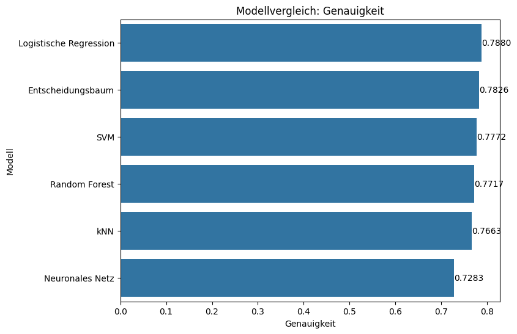

```python
# Vergleich der Modelle
model_results = {
    "kNN": accuracy_score(y_test, y_pred_knn),
    "SVM": accuracy_score(y_test, y_pred_svm),
    "Logistische Regression": accuracy_score(y_test, y_pred_log),
    "Entscheidungsbaum": accuracy_score(y_test, y_pred_tree),
    "Neuronales Netz": accuracy_score(y_test, y_pred_mlp),
    "Random Forest": accuracy_score(y_test, y_pred_forest),
}

# Darstellung der Ergebnisse
results_df = pd.DataFrame(list(model_results.items()), columns=["Modell", "Genauigkeit"])
results_df = results_df.sort_values(by="Genauigkeit", ascending=False)

# Visualisierung der Genauigkeit
plt.figure(figsize=(8, 6))
ax = sns.barplot(x="Genauigkeit", y="Modell", data=results_df)
plt.title("Modellvergleich: Genauigkeit")

# Exakte Werte anzeigen
for i in ax.containers:
    ax.bar_label(i, fmt='%.4f')

plt.show()
```

Die eingesetzten Klassifikationsverfahren erzielten eine Präzision von knapp unter 80 % und zeigen, dass die Modelle in der Lage sind, die Klassen *KHK vorhanden* und *KHK nicht vorhanden* in einem Großteil der Fälle korrekt zu unterscheiden. Da fast alle Modelle ähnliche Ergebnisse liefern und die Testdaten mit einem *random_state* erstellt wurden, lässt sich hier kein "bestes" Modell finden. Im folgenden Abschnitt versuchen wir die bisherige Genauigkeit eines ausgewählten Modells erhöhen.

## 6. Optimierung der Modelle

Wir verwenden das aus der Vorlesung bekannte Modell *Support Vector Machine* (SVM). Zu Beginn verwenden wir eine sog. *GridSearch* zur Optimierung der Parameter.

Wir übergeben der *GridSearch* zu Beginn eine breite Auswahl von Parametern, um zunächst eine grobe Eingrenzung der optimalen Werte zu erzielen. Diese Eingrenzung dient als Grundlage, um in einem zweiten Schritt eine detailliertere Feinjustierung vorzunehmen.

```python
svm_class = SVC(kernel='rbf', random_state=1)
param_grid = {'C': [1, 5, 10, 50, 100, 200, 300],
              'gamma': [0.0001, 0.0005, 0.001, 0.005, 0.01, 0.1, 1, 1.5]}
grid = GridSearchCV(svm_class, param_grid, cv= StratifiedKFold(n_splits=10))
grid.fit(X_train_scaled, y_train)

grid.best_params_
```

```
{'C': 1, 'gamma': 0.01}
```

Um diese Parameter zu testen, definieren wir eine Funktion mit zwei Eingabevariablen, die das SVM Modell trainiert und die Genauigkeit zurückgibt:

```python
def SVM(C, gamma):
    # SVM-Modell mit den angegebenen Parametern
    svm = SVC(C=C, gamma=gamma, kernel="rbf", random_state=1)
    svm.fit(X_train_scaled, y_train)
    y_pred_svm = svm.predict(X_test_scaled)

    # Genauigkeit berechnen & ausgeben
    print(accuracy_score(y_test, y_pred_svm))
```

Nun testen wir die SVM mit den Parametern:

```python
SVM(1, 0.01)
```

```
0.8043478260869565
```

Nun wollen wir diese Parameter weiter verfeinern, um unsere SVM weiter zu optimieren:

```python
param_grid = {'C': [0.6, 0.7, 0.85, 1, 1.5, 2, 2.5],
              'gamma': [0.004, 0.006, 0.008, 0.01, 0.012, 0.014, 0.016, 0.018]}
grid = GridSearchCV(svm_class, param_grid, cv= StratifiedKFold(n_splits=10))
grid.fit(X_train_scaled, y_train)
grid.best_params_
```

```
{'C': 0.85, 'gamma': 0.014}
```

Wir testen die verfeinerten Parameter 𝐶 = 0.85 und 𝛾 = 0.014:

```python
SVM(0.85, 0.014)
```

```
0.8043478260869565
```

Dies hat zu keiner Verbesserung geführt ... wahrscheinlich, da die zuvor getesteten Parameter bereits nahe am Optimum lagen und die Modellleistung in diesem Bereich stabil ist.

Daher visualisieren wir nun die Ausgabe der letzen GridSearch als Heatmap, um die Ergebnisse der GridSearch visuell zu analysieren und mögliche Muster oder Trends in den Parametereinstellungen zu identifizieren.

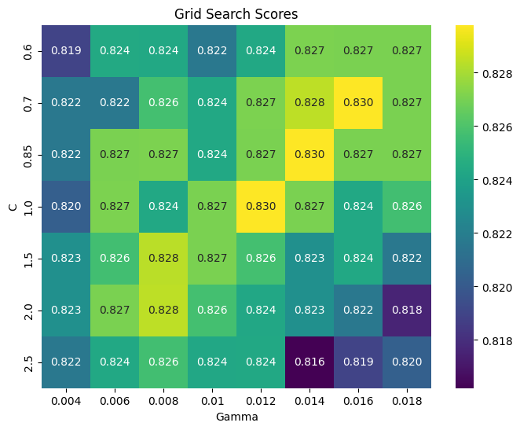

```python
# Visualize the results of the grid search
results = pd.DataFrame(grid.cv_results_)
scores = results.pivot(index="param_C", columns="param_gamma", values="mean_test_score")

plt.figure(figsize=(8, 6))
sns.heatmap(scores, annot=True, fmt=".3f", cmap="viridis")
plt.title("Grid Search Scores")
plt.xlabel("Gamma")
plt.ylabel("C")
plt.show()
```

Hier lässt sich erkennen, dass es insgesamt drei Kombinationen von 𝐶 und 𝛾 gibt, die den höchsten Score (0.830) haben. Wir haben bisher aber nur die Kombination 𝐶 = 0.85 und 𝛾 = 0.014 getestet, welche zu keiner Verbesserung führte.

Im Folgenden testen wir nun die anderen beiden Kombinationen 𝐶 = 1, 𝛾 = 0.012 und 𝐶 = 0.7, 𝛾 = 0.016:

```python
SVM(1, 0.012)
SVM(0.7, 0.016)
```

```
0.8043478260869565
```

```
0.8152173913043478
```

Die Kombination 𝐶 = 1 & 𝛾 = 0.012 führt ebenfalls zu keiner Verbesserung, die Kombination 𝐶 = 0.7 & 𝛾 = 0.016 hingegen schon! Mit den Parametern 𝐶 = 0.7 & 𝛾 = 0.016 wird die Genauigkeit der SVM auf 0.8152173913043478 angehoben. Dies entspricht einer Verbesserung von ca. 1,09%!

Da die *GridSearch* hier an ihre Grenzen zu stoßen scheint, wird die Optimierung der SVM im Folgenden durch gezieltes Feature Engineering forgesetzt:

### 6.1 Automatic Feature Engineering

Wir betrachten zwei unterschiedliche Möglichkeiten von automatischen Feature Engineering Methoden und testen diese auf unserem optimierten SVM Modell. Dafür implementieren wir zunächst eine Testfunktion des optimierten SVM Modells:

```python
def SVM_Optimized(X_train_scaled, X_test_scaled):
    # SVM-Modell mit den angegebenen Parametern
    svm = SVC(C=0.7, gamma=0.016, kernel="rbf", random_state=1)
    svm.fit(X_train_scaled, y_train)
    y_pred_svm = svm.predict(X_test_scaled)

    # Genauigkeit berechnen & ausgeben
    print(accuracy_score(y_test, y_pred_svm))
```

Nun implementieren wir einen Test mit Interaktionstermini und testen die Genauigkeit mit der Testfunktion:

```python
# Interaktionstermini erzeugen
poly = PolynomialFeatures(degree=2, interaction_only=True, include_bias=False)
X_train_poly = poly.fit_transform(X_train_scaled)
X_test_poly = poly.transform(X_test_scaled)

SVM_Optimized(X_train_poly, X_test_poly)
```

```
0.7717391304347826
```

Die Genauigkeit des Modells wurde verschlechtert ... Als nächsten testen wir eine PCA:

```python
# PCA anwenden
pca = PCA(n_components=10)  # 10 Hauptkomponenten
X_train_pca = pca.fit_transform(X_train_scaled)
X_test_pca = pca.transform(X_test_scaled)

SVM_Optimized(X_train_pca, X_test_pca)
```

```
0.8152173913043478
```

Die Genauigkeit des Modells bleibt identisch. Da die automatischen Optimierungsalgorithmen uns nicht zu helfen scheinen, wenden wir uns einer manuellen Optimierung durch die Analyse von Korrelationen und den sog. Feature Importance Werten zu.

### 6.2 Manual Feature Engineering

Zuerst betrachten wir die Korrelation einzelner Werte mit der Zielvariablen (Dieser Plot wurde bereits in Abschnitt 3.3 der explorativen Datenanalyse kurz betrachtet, hier jetzt im Kontext des Feature Engineering)

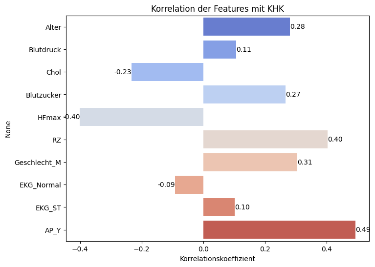

```python
khk_corr_plot # Wir verwenden den gespeicherten Plot aus Abschnitt 3.3
```

Und die Korrelation der Werte untereinander:

```
Geschlecht_M    2.009811
Blutdruck       2.125782
Blutzucker      2.164855
Chol            2.187446
RZ              2.370236
EKG_Normal      2.411709
EKG_ST          2.599268
AP_Y            2.617020
HFmax           2.883610
Alter           2.910357
dtype: float64
```

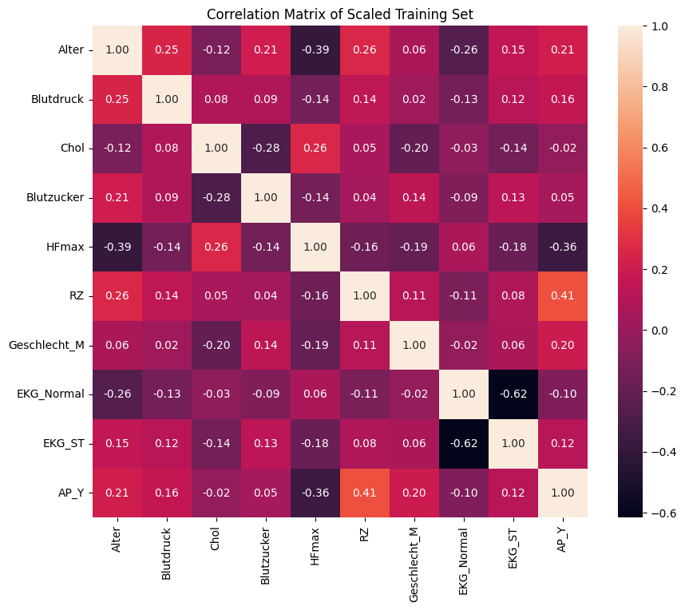

```python
# Convert the scaled training set back to a DataFrame for easier correlation calculation
X_train_scaled_df = pd.DataFrame(X_train_scaled, columns=X.columns)

# Calculate the correlation matrix
correlation_matrix_scaled = X_train_scaled_df.corr()

# Summe der absoluten Korrelationswerte jeder Variablen berechnen
correlation_sums = correlation_matrix_scaled.abs().sum().sort_values()

print(correlation_sums)

# Display the correlation matrix
plt.figure(figsize=(10, 8))
sns.heatmap(correlation_matrix_scaled, annot=True, fmt=".2f")
plt.title("Correlation Matrix of Scaled Training Set")
plt.show()
```

Bevor wird aus diesem Plot konkrete Maßnahmen ableiten, betrachten wir zunächst weitere Methoden die Feature Importance Werte bestimmen, um einen umfassenden Überblick zu erhalten.

Wir beginnen mit einer Permutation:

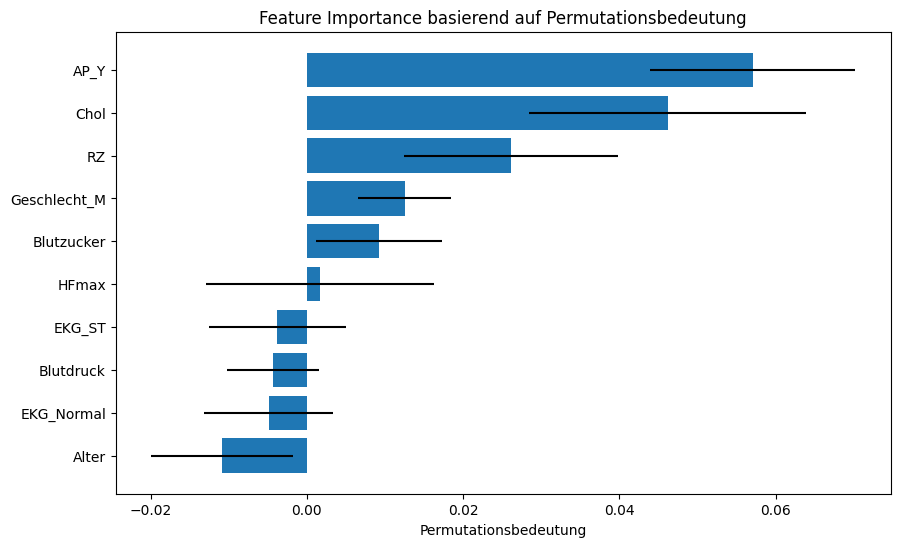

```python
# Berechnung der Permutationsbedeutung
result = permutation_importance(svm, X_test_scaled, y_test, n_repeats=10, random_state=1)

# Visualisierung der Permutationsbedeutung
sorted_idx = result.importances_mean.argsort()

plt.figure(figsize=(10, 6))
plt.barh(range(len(sorted_idx)), result.importances_mean[sorted_idx], xerr=result.importances_std[sorted_idx])
plt.yticks(range(len(sorted_idx)), X.columns[sorted_idx])
plt.xlabel("Permutationsbedeutung")
plt.title("Feature Importance basierend auf Permutationsbedeutung")
plt.show()
```

Wir machen weiter mit dem RandomForestClassifier:

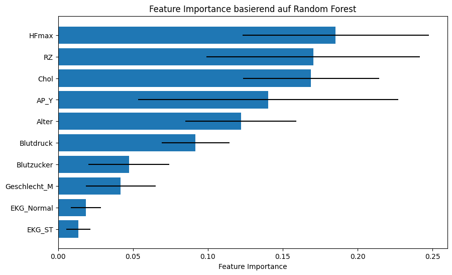

```python
# Random Forest Modell trainieren
rf = RandomForestClassifier(n_estimators=1000, random_state=1)
rf.fit(X_train_scaled, y_train)

# Berechnung der Feature Importance
importances = rf.feature_importances_
std = np.std([tree.feature_importances_ for tree in rf.estimators_], axis=0)
indices = np.argsort(importances)

# Visualisierung der Feature Importance
plt.figure(figsize=(10, 6))
plt.barh(range(len(indices)), importances[indices], xerr=std[indices])
plt.yticks(range(len(indices)), X.columns[indices])
plt.xlabel("Feature Importance")
plt.title("Feature Importance basierend auf Random Forest")
plt.show()
```

Und schließen mit dem GradientBoostingClassifier ab:

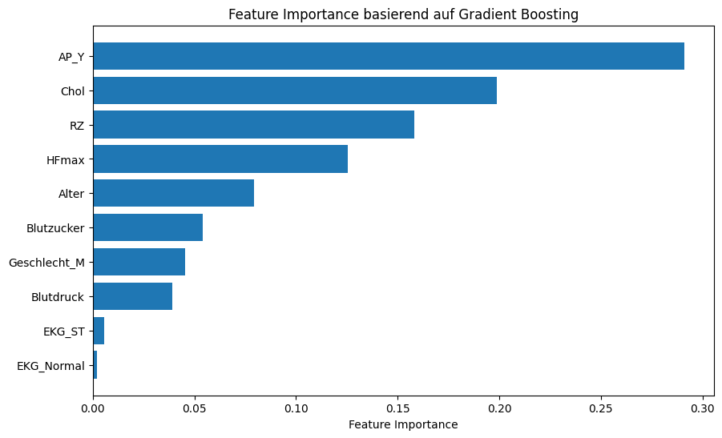

```python
# Gradient Boosting Modell trainieren
gb = GradientBoostingClassifier(n_estimators=100, random_state=1)
gb.fit(X_train_scaled, y_train)

# Berechnung der Feature Importance
importances_gb = gb.feature_importances_
indices_gb = np.argsort(importances_gb)

# Visualisierung der Feature Importance
plt.figure(figsize=(10, 6))
plt.barh(range(len(indices_gb)), importances_gb[indices_gb])
plt.yticks(range(len(indices_gb)), X.columns[indices_gb])
plt.xlabel("Feature Importance")
plt.title("Feature Importance basierend auf Gradient Boosting")
plt.show()
```

Jetzt liegen uns ingesamt fünf verschiedene Datensätze vor, die uns jeweils die Features und ihre Beziehungen näherbringen.

Jetzt wollen wir mit den neu gewichteten Variablen unsere SVM testen. Zu Beginn implementieren wird eine Testfunktion, welche den Traingsdatensatz mit den übergeben Paramatern manipuliert (gewichtet) und testet:

```python
def evaluate_feature_weights(weights):
    X_train_weighted = X_train_scaled.copy()
    X_test_weighted = X_test_scaled.copy()

    for feature, weight in weights.items():
        feature_index = X.columns.get_loc(feature)
        X_train_weighted[:, feature_index] *= weight
        X_test_weighted[:, feature_index] *= weight

    svm = SVC(C=0.7, gamma=0.016, kernel="rbf", random_state=1)
    svm.fit(X_train_weighted, y_train)
    y_pred_svm = svm.predict(X_test_weighted)

    print(accuracy_score(y_test, y_pred_svm))
```

Jetzt erstellen wir den Eingabeparameter aus den zuvor ermittelten *weights*:

```python
# Manuelle Gewichtung der Features
feature_weights = {
    'Alter': 1.5,
    'Blutdruck': 0.0,
    'Chol': 1.0,
    'Blutzucker': 0.5,
    'HFmax': 0.5,
    'RZ': 1.5,
    'Geschlecht_M': 2.0,
    'EKG_Normal': 0.0,
    'EKG_ST': 0.0,
    'AP_Y': 1.5
}
```

Und testen unser Modell mit dem gewichteten Datensatz:

```python
evaluate_feature_weights(feature_weights)
```

```
0.8206521739130435
```

Dies entspricht einer weiteren Verbesserung um ca. 0.54%!

Durch fortlaufendes Testing optimieren wir die *weights* weiter. Folgende *weights* ...

```python
# Manuelle Gewichtung der Features
feature_weights = {
    'Alter': 1.4,
    'Blutdruck': 0.0,
    'Chol': 0.9,
    'Blutzucker': 0.4,
    'HFmax': 0.4,
    'RZ': 1.4,
    'Geschlecht_M': 1.9,
    'EKG_Normal': 0,
    'EKG_ST': 2,
    'AP_Y': 1.3
}
```

... führen zu einer weiteren Verbesserung der SVM ...

```python
accuracy = evaluate_feature_weights(feature_weights)
```

```
0.8315217391304348
```

... auf ca. 83, 15% Genauigkeit. Dies entspricht einer weiteren Verbesserung von ca. 1,09%!

## 7. Auswertung und Fazit

In diesem Abschnitt testen und vergleichen wir die optimierte SVM mit und ohne *Feature Weights* sowie die nicht optimierte SVM auf vielen unterschiedlich *gesplitteten* Datensätzen (andere *random states* beim *splitten*). Abschließend ziehen wir ein Fazit.

### 7.1 Auswertung

Zuerst implementieren wir eine Testfunktion für die optimierte SVM mit *Feature weights*, die Traingsdaten als Parameter akzeptiert und die Genaugikeit für Vorhersagen auf diesen Daten ausgibt:

```python
def test_optimized_svm_with_feature_weights(X_train_scaled, X_test_scaled, y_train, y_test):
    feature_weights = {
        'Alter': 1.4,
        'Blutdruck': 0.0,
        'Chol': 0.9,
        'Blutzucker': 0.4,
        'HFmax': 0.4,
        'RZ': 1.4,
        'Geschlecht_M': 1.9,
        'EKG_Normal': 0,
        'EKG_ST': 2,
        'AP_Y': 1.3
    }

    X_train_weighted = X_train_scaled.copy()
    X_test_weighted = X_test_scaled.copy()

    for feature, weight in feature_weights.items():
        feature_index = X.columns.get_loc(feature)
        X_train_weighted[:, feature_index] *= weight
        X_test_weighted[:, feature_index] *= weight

    svm = SVC(C=0.7, gamma=0.016, kernel="rbf", random_state=1)
    svm.fit(X_train_weighted, y_train)
    y_pred_svm = svm.predict(X_test_weighted)

    return accuracy_score(y_test, y_pred_svm)
```

Die Implementierung der Testfunktion für die optimierte SVM ohne *Feature weights* erfolgt analog:

```python
def test_optimized_svm(X_train_scaled, X_test_scaled, y_train, y_test):
    svm = SVC(C=0.7, gamma=0.016, kernel="rbf", random_state=1)
    svm.fit(X_train_scaled, y_train)
    y_pred_svm = svm.predict(X_test_scaled)

    return accuracy_score(y_test, y_pred_svm)
```

Abschließend fehlt nur noch die unoptimierte SVM:

```python
def test_svm(X_train_scaled, X_test_scaled, y_train, y_test):
    svm = SVC(kernel="rbf", random_state=1)
    svm.fit(X_train_scaled, y_train)
    y_pred_svm = svm.predict(X_test_scaled)

    return accuracy_score(y_test, y_pred_svm)
```

Wir implementieren die Testfunktion, mit der wir diese Modelle auf unterschiedlichen Traingsdatensätzen anwenden und die jeweilige minimale, maximale und durchschnittliche Genauigkeit berechnen. Die Ausgabe der Ergebnisse erfolgt durch einen Plot:

```python
def svm_vergleich(random_states_from_0_to):
    # Listen zur Speicherung der Genauigkeiten
    accuracies_svm = []
    accuracies_optimized_svm = []
    accuracies_optimized_svm_with_weights = []

    # Schleife über die verschiedenen Random States
    for random_state in range(random_states_from_0_to):
        X_train, X_test, y_train, y_test = train_test_split(X, y, test_size=0.2, random_state=random_state, stratify=y)

        # Daten standardisieren
        X_train_scaled = scaler.fit_transform(X_train)
        X_test_scaled = scaler.transform(X_test)

        # Unoptimierte SVM testen
        accuracy_svm = test_svm(X_train_scaled, X_test_scaled, y_train, y_test)
        accuracies_svm.append(accuracy_svm)

        # Optimierte SVM testen
        accuracy_optimized_svm = test_optimized_svm(X_train_scaled, X_test_scaled, y_train, y_test)
        accuracies_optimized_svm.append(accuracy_optimized_svm)

        # Optimierte SVM mit Feature-Gewichtungen testen
        accuracy_optimized_svm_with_weights = test_optimized_svm_with_feature_weights(X_train_scaled, X_test_scaled, y_train, y_test)
        accuracies_optimized_svm_with_weights.append(accuracy_optimized_svm_with_weights)

    # Min-, Mittel- und Max-Genauigkeiten berechnen
    min_accuracies = [np.min(accuracies_svm), np.min(accuracies_optimized_svm), np.min(accuracies_optimized_svm_with_weights)]
    mean_accuracies = [np.mean(accuracies_svm), np.mean(accuracies_optimized_svm), np.mean(accuracies_optimized_svm_with_weights)]
    max_accuracies = [np.max(accuracies_svm), np.max(accuracies_optimized_svm), np.max(accuracies_optimized_svm_with_weights)]

    # Daten als Plot anzeigen
    plt.figure(figsize=(10, 6))
    x_labels = ['Unoptimierte SVM', 'Optimierte SVM', 'Optimierte SVM mit Gewichtungen']
    accuracies_df = pd.DataFrame({
        'Modell': x_labels,
        'Minimale Genauigkeit': min_accuracies,
        'Mittlere Genauigkeit': mean_accuracies,
        'Maximale Genauigkeit': max_accuracies
    })

    accuracies_df = accuracies_df.melt(id_vars='Modell', var_name='Metrik', value_name='Genauigkeit')

    ax = sns.barplot(x='Modell', y='Genauigkeit', hue='Metrik', data=accuracies_df)

    # Exakte Werte im Plot anzeigen
    for container in ax.containers:
        ax.bar_label(container, fmt='%.3f')

    plt.xlabel('Modell')
    plt.ylabel('Genauigkeit')
    plt.title('Vergleich der SVM-Modelle')
    plt.legend(title='Metrik')
    plt.show()
```

Wir führen die Funktion aus und testen die SVMs auf 50 unterschiedlichen Datensätzen (random state 0 bis 49):

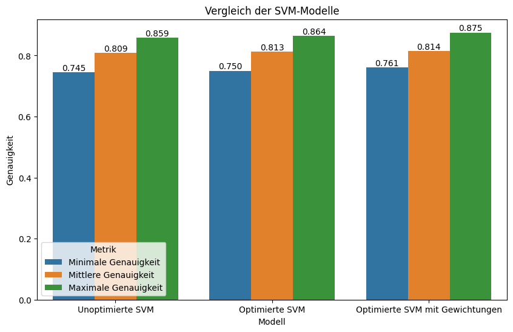

```python
svm_vergleich(50)
```

Unser optimiertes Modell mit Gewichtungen schlägt die anderen beiden in allen drei Kategorien! Zusätzlich schlägt das optimierte Modell ohne Gewichtungen das Standardmodell ebenfalls in allen Kategorien.

### 7.2 Fazit

**Optimierte SVM-Parameter:**

| Parameter | Wert |
| --- | --- |
| C | 0.7 |
| Gamma | 0.016 |
| Kernel | rbf |
| Random State | 1 |

**Feature-Gewichtungen:**

| Feature | Gewichtung |
| --- | --- |
| Alter | 1.4 |
| Blutdruck | 0.0 |
| Chol | 0.9 |
| Blutzucker | 0.4 |
| HFmax | 0.4 |
| RZ | 1.4 |
| Geschlecht_M | 1.9 |
| EKG_Normal | 0 |
| EKG_ST | 2 |
| AP_Y | 1.3 |

## 8. Quellen

Die Dokumentationen der verwendeten Bibliotheken.

- [pandas](https://pandas.pydata.org/)
- [numpy](https://numpy.org/)
- [matplotlib](https://matplotlib.org/)
- [seaborn](https://seaborn.pydata.org/)
- [sklearn](https://scikit-learn.org/stable/)